# Data Visualization (Electrodes)

This article uses `N27` sample files mentioned by the previous vignettes. If you are using this example, please execute the following R code to set up. Alternatively, you can substitute variables `subject_code` and `subject_path` accordingly.

```r
library(threeBrain)
subject_code <- "N27"
subject_path <- "~/Downloads/N27"
brain <- freesurfer_brain2(subject_path, subject_code)
```

## Add Electrodes

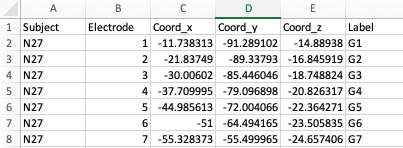

Electrode table - example

If you have performed electrode localization (see the previous article) and exported the electrode table, the exported table can be used here once `Electrode` is filled out.

For demonstration purposes, this [electrode table](https://raw.githubusercontent.com/dipterix/threeBrain-sample/master/vignettes/electrodes.csv) will be used. Please download this file and place it at `~/Downloads/N27/electrodes.csv`

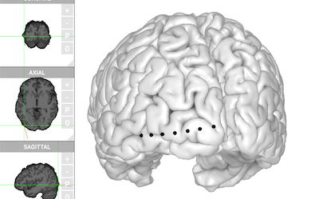

Click on one of the electrodes, the information (label, ‘MNI’ coordinates) will be displayed at top.

```r
electrode_table <- `~/Downloads/N27/electrodes.csv`
brain$set_electrodes(electrode_table)
brain$plot()
```

## Add Electrode Values

In iEEG study, various of analyses can be performed on the electrodes. The analysis results are different, including

- functional data such as mean-response over time
- continuous data like p-values, z-scores
- categorical data such as cluster labels

`threeBrain` can visualize them all with two lines and one data table.

| Project | Subject | Electrode | Time | sine_wave | p_value | z_score | cluster |
| --- | --- | --- | --- | --- | --- | --- | --- |
| demo | N27 | 1 | 0.00 | 0.20 | 0.05 | 1.96 | A |
| demo | N27 | 1 | 0.50 | 0.88 | 0.05 | 1.96 | A |
| demo | N27 | 1 | 1.00 | 0.98 | 0.05 | 1.96 | A |
| demo | N27 | 2 | 0.00 | 0.38 | 0.01 | 2.58 | A |
| demo | N27 | 2 | 0.44 | 0.89 | 0.01 | 2.58 | A |
| demo | N27 | 2 | 0.89 | 0.98 | 0.01 | 2.58 | A |
| demo | N27 | 3 | 0.00 | 0.56 | 0.28 | 1.09 | A |
| demo | N27 | 3 | 0.11 | 0.69 | 0.28 | 1.09 | A |
| … |  |  |  |  |  |  |  |

The column names are case-sensitive, and should only contain letters, digits and `_`.

- `Project`: (optional) the project name that this experiment belongs to
- `Subject`: (mandatory) the subject code; must be consistent with the brain subject code
- `Electrode`: (mandatory) integers of electrode channel number; correspond to the `Electrode` column in the electrode table
- `Time` (optional) numerical time in seconds
- Value columns (such as `sine_wave`, `p_value`, `z_score`, and `cluster`): values of the electrodes

Download sample value table from [here](https://github.com/dipterix/threeBrain-sample/blob/master/vignettes/values.csv) and save it to `~/Downloads/N27/values.csv`

```r
electrode_table <- `~/Downloads/N27/electrodes.csv`
value_table <- `~/Downloads/N27/values.csv`
brain$set_electrodes(electrode_table)
brain$set_electrode_values(value_table)
brain$plot()
```

Open `Data Visualization` panel, change `Display Data` or use keyboard shortcut `d` (make sure the mouse is hovering on the brain) to switch to desired variables.

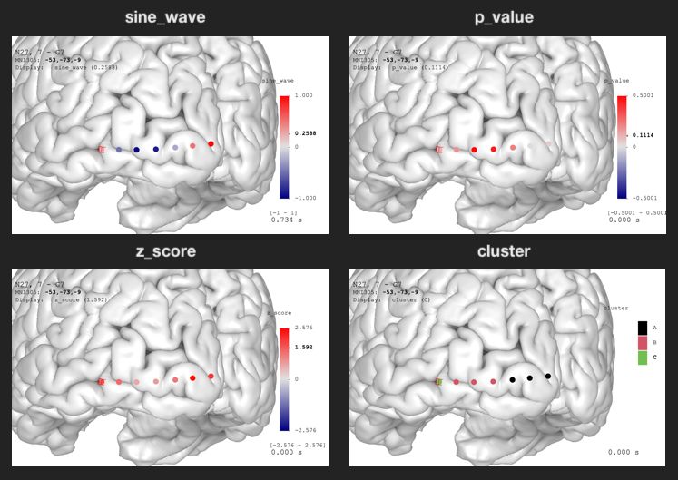

Electrode data visualization. For continuous data, the value range is automatically detected using the maximum absolute values. The color palette goes from blue to white to red with linear transition. For discrete data, the color palette uses R’s default palette.

The `sine_wave` is time series. You can see the animation by toggling `Play/Pause` option in the `Data Visualization` panel.

### Change Color Palette

In the example above, the p-value legend shows the range is from `-0.5` to `0.5`. This is because `threeBrain` viewer’s default palette is symmetric around zero, and the range is decided by the maximum absolute number. However, the actual p-value should range from `0` to `1`, and we might be particularly interested in `$p \leq 0.05$`. This means both the color palette and value range need to be corrected.

In the following code, `value_ranges` is a named list of such value ranges. `"p_value"=c(0,1)` suggests that the `p_value` variable should range from 0 to 1. All other variables adopt the default ranges. `palettes` is a named list of color palettes. In this specific case, variable `pal` is a vector of 64 colors. `colorRampPalette` is a base-R function to interpolate colors. Please use `help("colorRampPalette")` to see the documentation.

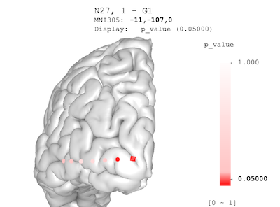

Adjusted p-value palette: the value range is from 0 to 1; the color transition is non-linear, with $p<0.05$ rendered as deep red, and large p-values rendered as light reds

```r
pal <- c(
  colorRampPalette(c("red", "#FFC6C6"))(8),
  colorRampPalette(c("#FFC6C6", "white"))(56)
)
brain$plot(
  value_ranges = list( "p_value" = c(0, 1) ),
  palettes = list( "p_value" = pal )
)
```

## Map Electrode Values to the Surface

`threeBrain` provides value mapping that allows electrode values to be displayed on the surfaces. To enable this feature, open `Surface Settings` panel, and click on `Surface Color`, switch to `sync from electrodes`, or simply use keyboard shortcut `k` (make sure the mouse is hovering over the brain) to change.

You can also hide the electrodes by switching the electrode `Visibility` to `hidden` in the `Electrodes` panel to only show the mapped results.

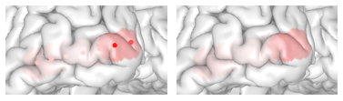

Electrode values (p-value) mapped on to the pial surface. Left: electrodes are visible; Right: electrodes are hidden.